# Caso 2(Principal)

Joan Lamprea y Jose Valdes

2023-05-04

# Caso 2 de bayesiana

## Base de datos

```r
# cargar los datos
load("D:/jose/CasoBayes2/Personas.Rdata")
# mira Na en ingtot
sum(is.na(dat$ingtot))
```

```
## [1] 0
```

Teniendo encuenta lo anterior extraeremos de la base de datos las varibles para el caso las cuales son **dominio** y **ingtot**. Organizamos los datos teniendo encuenta que:

1. Recordamos que la función log tiene base $e$.
2. La varaible **dominio** es un factor

```r
#datos que voy a usar
Data <- data.frame(dat$dominio, dat$ingtot)
#nombres
names(Data) <- c("Dominio","Ingtot")
# pasamos los Ingtot a escala logaritmica
Data[,2] <- log(Data$Ingtot)
# presentar datos
head(Data)
```

```
##   Dominio   Ingtot
## 1 ARMENIA 15.11910
## 2 ARMENIA 14.22098
## 3 ARMENIA 15.00162
## 4 ARMENIA 10.81978
## 5 ARMENIA 14.22098
## 6 ARMENIA 14.07643
```

```r
# comprobar media,varianza  y precisión
mean(Data$Ingtot)
```

```
## [1] 13.49516
```

```r
var(Data$Ingtot)
```

```
## [1] 1.181517
```

```r
1/var(Data$Ingtot)
```

```
## [1] 0.8463697
```

```r
# volver factor domionio
class(Data$Dominio)
```

```
## [1] "character"
```

```r
Data[,1] <- as.factor(Data$Dominio)
summary(Data$Dominio)
```

```
##       ARMENIA  BARRANQUILLA        BOGOTA   BUCARAMANGA          CALI
##           133           214           165           125           166
##     CARTAGENA        CUCUTA     FLORENCIA        IBAGUE     MANIZALES
##           131           115            99            94           157
##      MEDELLIN      MONTERIA         NEIVA         PASTO       PEREIRA
##           235           102           110           133           114
##       POPAYAN        QUIBDO  RESTO URBANO      RIOHACHA         RURAL
##           116            82           414           101           345
##   SANTA MARTA     SINCELEJO         TUNJA    VALLEDUPAR VILLAVICENCIO
##           131           154           116           155           113
```

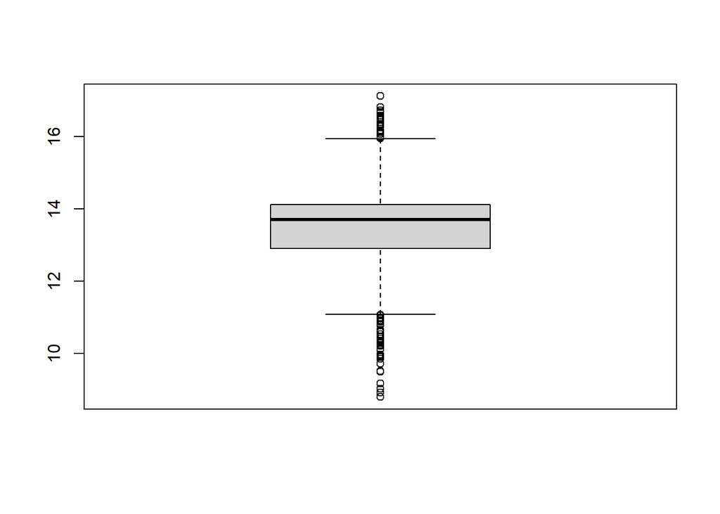

```r
#boxplot
boxplot(Data$Ingtot)
```

Ahora con esto obtendremos los datos que nos son relevantes para eltrabajo  
desde la base de datos cómo:

```r
# m <- Cantidad de dominios (Departamentos)
m <- length(table(Data$Dominio))
m
```

```
## [1] 25
```

```r
# n <- número de individuos
n <- sum(table(Data$Dominio))
n
```

```
## [1] 3820
```

```r
# y <- vector con los datos
y <- Data$Ingtot
head(y)
```

```
## [1] 15.11910 14.22098 15.00162 10.81978 14.22098 14.07643
```

Obtendremos una tabla con los estadísticos necesarios por dominio para trabajar con las distribuciones condicionales completas y tener una idea de los datos.

1. la función **n()** solo funciona dentro de una funcion actual como summarise en el estado actual y devuelve el tamaño del grupo

```r
# tabla con los estadisticos
Estadisticos <- Data %>%
      group_by(Dominio) %>%
      summarise(Dominio = unique(Dominio), nj = n(), yb = mean(Ingtot),
                s2 = var(Ingtot))
head(Estadisticos)
```

```
## # A tibble: 6 × 4
##   Dominio         nj    yb    s2
##   <fct>        <int> <dbl> <dbl>
## 1 ARMENIA        133  13.6  1.26
## 2 BARRANQUILLA   214  13.4  1.16
## 3 BOGOTA         165  13.8  1.38
## 4 BUCARAMANGA    125  13.8  1.06
## 5 CALI           166  13.6  1.18
## 6 CARTAGENA      131  13.4  1.08
```

```r
# almacenar info importante
nj <- Estadisticos$nj
yb <- Estadisticos$yb
s2 <- Estadisticos$s2
```

## Modelo 1

Hiperparámetros del modelo.

$\textsf{M}_1$: $\mu_0 = 13.495$, $\gamma_0^2 = 11.382$, $\nu_0 = 1$, $\sigma^2_0 = 1.182$.

Ejecución del modelo

```r
#ajustar modelo
tictoc::tic()
set.seed(1856)
cadena1_M1 <- MCMC_1(y,B = 11000)
tictoc::toc()
```

```
## 2.97 sec elapsed
```

### Convergencia

Usaremos la log-verosimilitud para mirar la convergencia de la cadena

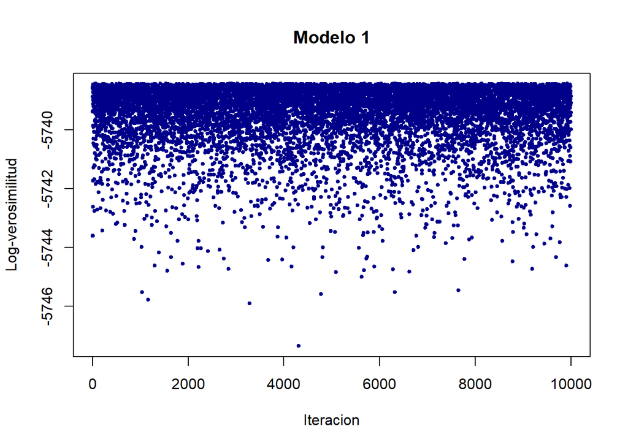

```r
# Gráfico
yrange <- range(cadena1_M1$LL$ll)
plot(cadena1_M1$LL$ll, type = "p", pch = 20, cex = 0.8, col = "darkblue", ylim = yrange, xlab = "Iteracion",ylab = "Log-verosimilitud", main = "Modelo 1")
```

## Modelo 2

Hiperparámetros del modelo.

$\textsf{M}_2$: $\mu_0 = 13.495$, $\gamma_0^2 = 11.382$, $\eta_0 = 1$, $\tau^2_0 = 1.182$, $\nu_0 = 1$, $\sigma^2_0 = 1.182$.

Ejecución del modelo

```r
#ajustar modelo
tictoc::tic()
set.seed(1856)
cadena1_M2 <- MCMC_2(y, B = 11000, nj, yb, s2)
tictoc::toc()
```

```
## 3.75 sec elapsed
```

### Convergencia

Usaremos la log-verosimilitud para mirar la convergencia de la cadena

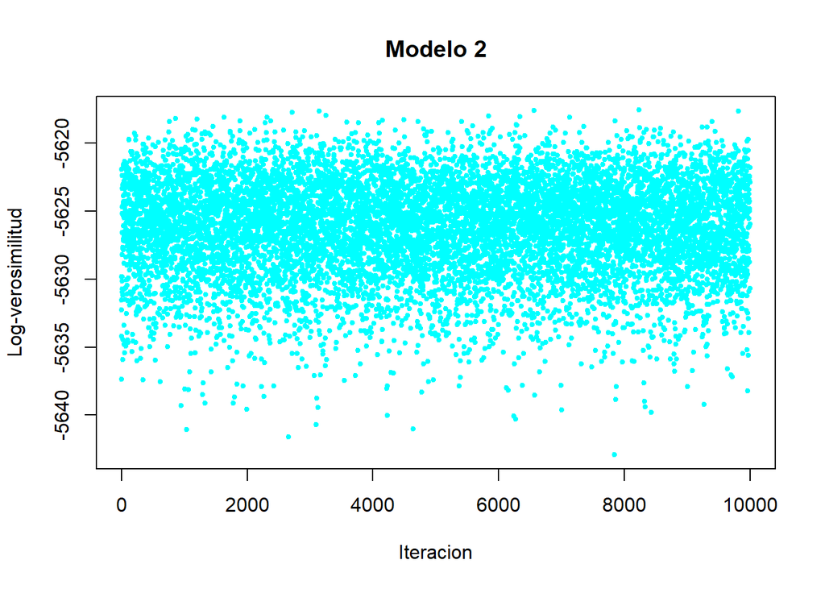

```r
# Gráfico
yrange <- range(cadena1_M2$LL$ll)
plot(cadena1_M2$LL$ll, type = "p", pch = 20, cex = 0.8, col = "cyan", ylim = yrange, xlab = "Iteracion",ylab = "Log-verosimilitud", main = "Modelo 2")
```

## Modelo 3

Hiperparámetros del modelo.

$\textsf{M}_3$: $\mu_0 = 13.495$, $\gamma_0^2 = 11.382$, $\eta_0 = 1$, $\tau^2_0 = 1.182$, $\nu = 1$, $\alpha_0 = 1$, $\beta_0 = 0.846$.

Ejecución del modelo

```r
#ajustar modelo
tictoc::tic()
set.seed(1856)
cadena1_M3 <- MCMC_3(y,B = 11000, nj, yb, s2)
tictoc::toc()
```

```
## 4 sec elapsed
```

### Convergencia

Usaremos la log-verosimilitud para mirar la convergencia de la cadena

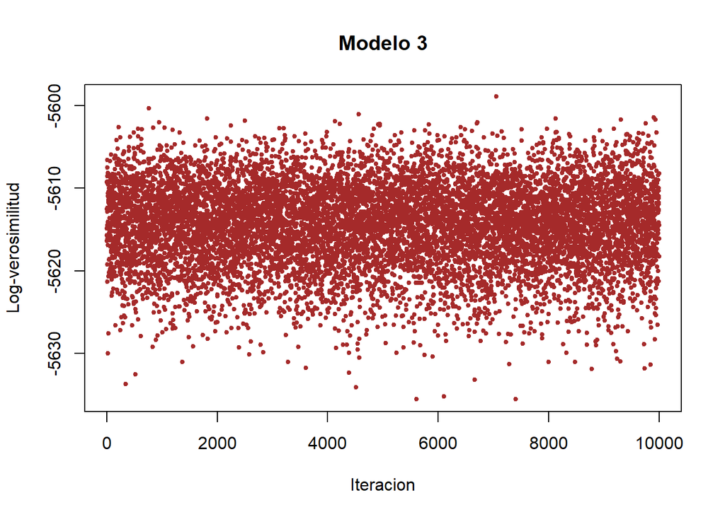

```r
# Gráfico
yrange <- range(cadena1_M3$LL$ll)
plot(cadena1_M3$LL$ll, type = "p", pch = 20, cex = 0.8, col = "brown", ylim = yrange,  xlab = "Iteracion",ylab = "Log-verosimilitud", main = "Modelo 3")
```

## Modelo 4

Hiperparámetros del modelo.

$\textsf{M}_4$: $\mu_0 = 13.495$, $\gamma_0^2 = 11.382$, $\alpha_0 = 1$, $\beta_0 = 0.846$, $\kappa = 3$.

Ejecución del modelo

```r
#ajustar modelo
tictoc::tic()
set.seed(1856)
cadena1_M4 <- MCMC_4(y,B = 11000, nj)
tictoc::toc()
```

```
## 11.28 sec elapsed
```

### Convergencia

Usaremos la log-verosimilitud para mirar la convergencia de la cadena

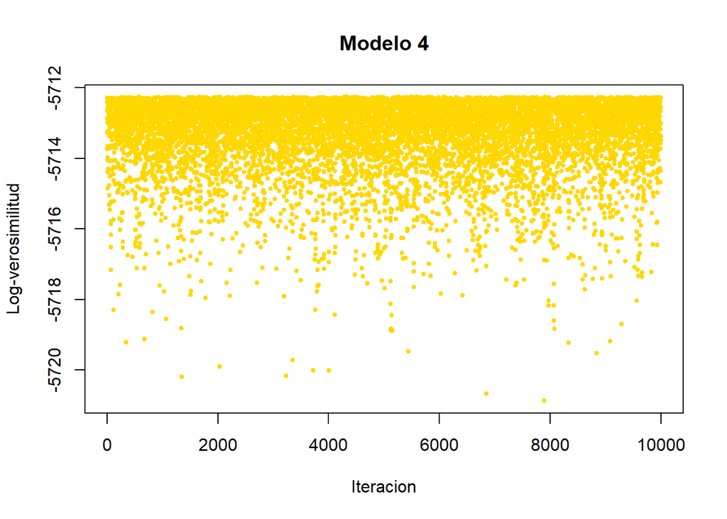

```r
# Gráfico
yrange <- range(cadena1_M4$LL$ll)
plot(cadena1_M4$LL$ll, type = "p", pch = 20, cex = 0.8, col = "gold", ylim = yrange, xlab = "Iteracion",ylab = "Log-verosimilitud", main = "Modelo 4")
```

## Modelo 5

Hiperparámetros del modelo.

$\textsf{M}_5$: $\mu_0 = 13.495$, $\gamma_0^2 = 11.382$, $\eta_0 = 1$, $\tau^2_0 = 1.182$, $\alpha_0 = 1$, $\beta_0 = 0.846$, $\kappa = 3$.

Ejecución del modelo

```r
#ajustar modelo
tictoc::tic()
set.seed(1856)
cadena1_M5 <- MCMC_5(y,B = 11000, nj, yb)
tictoc::toc()
```

```
## 12 sec elapsed
```

### Convergencia

Usaremos la log-verosimilitud para mirar la convergencia de la cadena

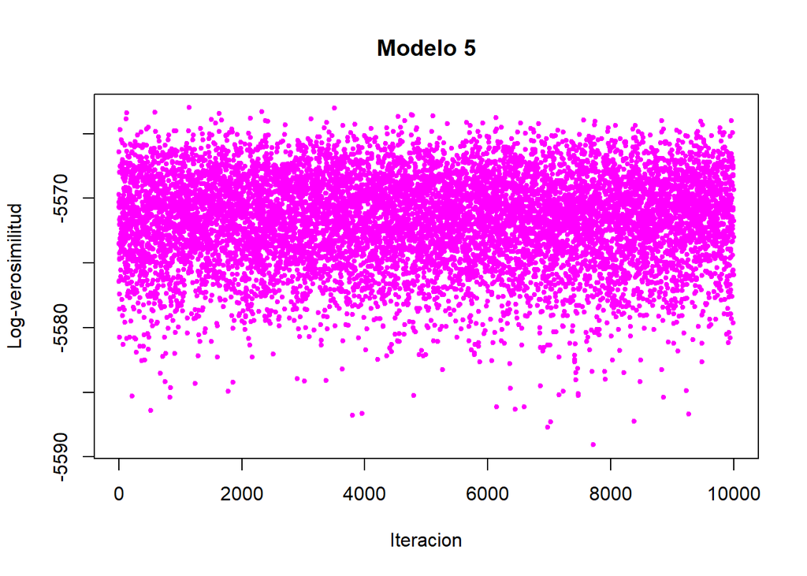

```r
# Gráfico
yrange <- range(cadena1_M5$LL$ll)
plot(cadena1_M5$LL$ll, type = "p", pch = 20, cex = 0.8, col = "magenta", ylim = yrange,  xlab = "Iteracion",ylab = "Log-verosimilitud", main = "Modelo 5")
```

## Modelo 6

Hiperparámetros del modelo.

$\textsf{M}_6$: $\mu_0 = 13.495$, $\gamma_0^2 = 11.382$, $\eta_0 = 1$, $\tau^2_0 = 1.182$, $\alpha = 1$, $a_\beta = 1$, $b_\beta = 1.182$, $\kappa = 3$.

Ejecución del modelo

```r
#ajustar modelo
tictoc::tic()
set.seed(1856)
cadena1_M6 <- MCMC_6(y,B = 11000, nj, yb)
tictoc::toc()
```

```
## 14.42 sec elapsed
```

### Convergencia

Usaremos la log-verosimilitud para mirar la convergencia de la cadena

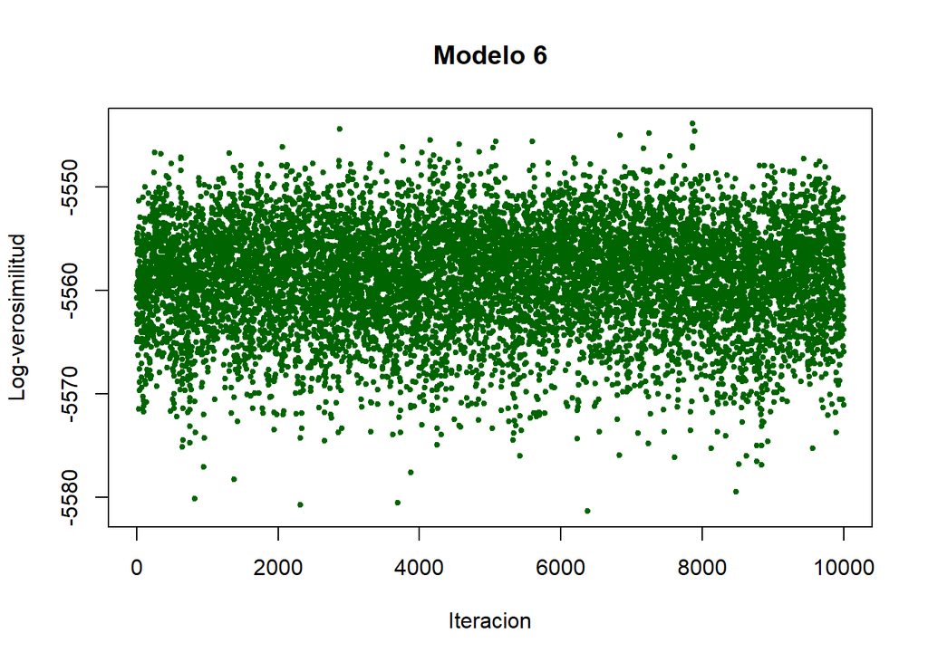

```r
# Gráfico
yrange <- range(cadena1_M6$LL$ll)
plot(cadena1_M6$LL$ll, type = "p", pch = 20, cex = 0.8, col = "darkgreen", ylim = yrange, xlab = "Iteracion",ylab = "Log-verosimilitud", main = "Modelo 6")
```

### modelos en un solo plot

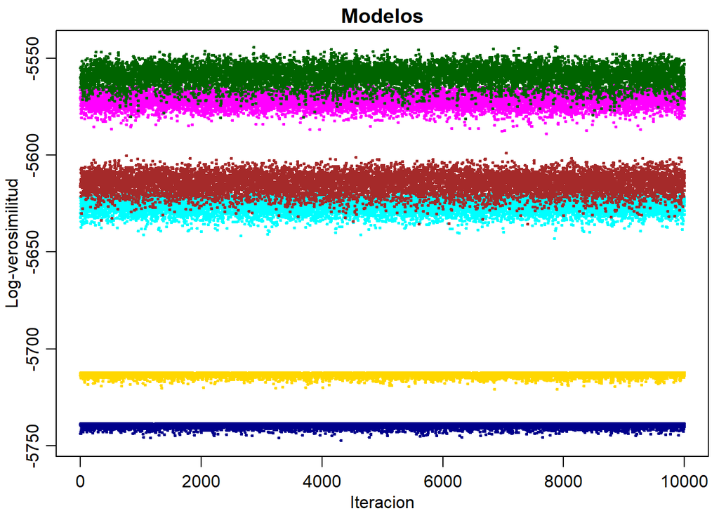

```r
# Gráfico
par(mfrow = c(1,1), mar = c(2.75,2.75,1.5,0.5), mgp=c(1.7,0.7,0))
#modelos normal
yrange <- range(cadena1_M1$LL$ll, cadena1_M2$LL$ll,cadena1_M3$LL$ll,cadena1_M4$LL$ll, cadena1_M5$LL$ll,cadena1_M6$LL$ll)
plot(cadena1_M1$LL$ll, type = "p", pch = 20, cex = 0.5, col = "darkblue", ylim = yrange, xlab = "Iteracion",ylab = "Log-verosimilitud", main = "Modelos")
lines(cadena1_M2$LL$ll, type = "p",pch = 20, cex = 0.5,col = "cyan")
lines(cadena1_M3$LL$ll, type = "p", pch = 20, cex = 0.5,col = "brown")
#modelos t
#yrange <- range(cadena1_M4$LL$ll, cadena1_M5$LL$ll,cadena1_M6$LL$ll)
#plot(cadena1_M4$LL$ll, type = "p", pch = 20, cex = 0.6, col = "lightblue", ylim = yrange,  xlab = "Iteración",ylab = "Log-verosimilitud", main = "Modelos t")
lines(cadena1_M4$LL$ll, type = "p", pch = 20, cex = 0.5,col = "gold")
lines(cadena1_M5$LL$ll, type = "p", pch = 20, cex = 0.5,col = "magenta")
lines(cadena1_M6$LL$ll, type = "p", pch = 20, cex = 0.5,col = "darkgreen")
```

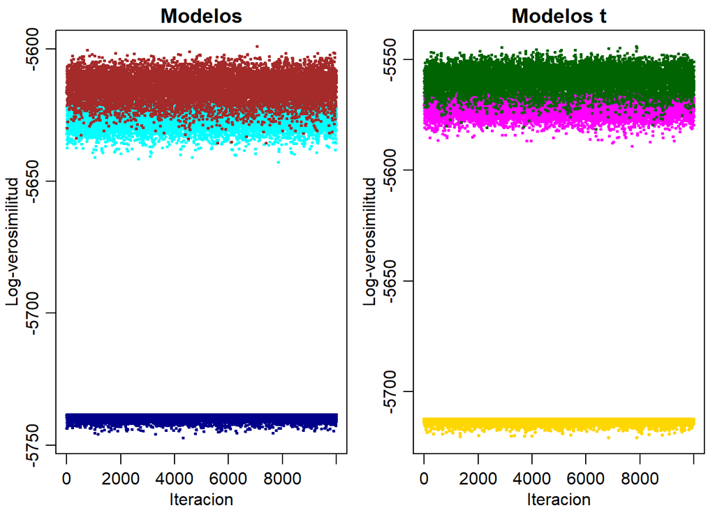

```r
# Gráfico
par(mfrow = c(1,2), mar = c(2.75,2.75,1.5,0.5), mgp=c(1.7,0.7,0))
#modelos normal
yrange <- range(cadena1_M1$LL$ll, cadena1_M2$LL$ll,cadena1_M3$LL$ll)
plot(cadena1_M1$LL$ll, type = "p", pch = 20, cex = 0.5, col = "darkblue", ylim = yrange, xlab = "Iteracion",ylab = "Log-verosimilitud", main = "Modelos")
lines(cadena1_M2$LL$ll, type = "p",pch = 20, cex = 0.5,col = "cyan")
lines(cadena1_M3$LL$ll, type = "p", pch = 20, cex = 0.5,col = "brown")
#modelos t
yrange <- range(cadena1_M4$LL$ll, cadena1_M5$LL$ll,cadena1_M6$LL$ll)
plot(cadena1_M4$LL$ll, type = "p", pch = 20, cex = 0.6, col = "gold", ylim = yrange,  xlab = "Iteracion",ylab = "Log-verosimilitud", main = "Modelos t")
#lines(cadena1_M4$LL$ll, type = "p", pch = 20, cex = 0.5,col = "gold")
lines(cadena1_M5$LL$ll, type = "p", pch = 20, cex = 0.5,col = "magenta")
lines(cadena1_M6$LL$ll, type = "p", pch = 20, cex = 0.5,col = "darkgreen")
```

## Comparación de modelos

primero hacremos un analsis de los modelos para su densidad

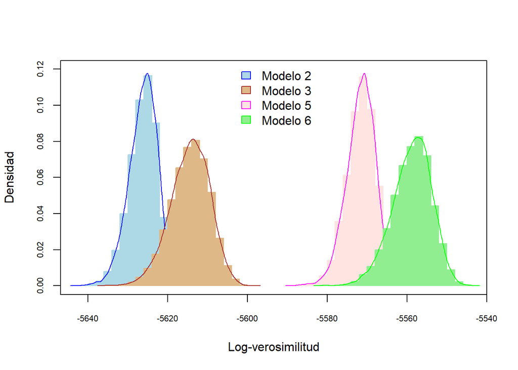

```r
#gráfico fondo
plot(x = NA, y = NA, ylab = "Densidad", xlab = "Log-verosimilitud", cex.axis = 0.7, xlim = range(as.numeric(cadena1_M5$LL$ll), as.numeric(cadena1_M6$LL$ll),as.numeric(cadena1_M2$LL$ll),as.numeric(cadena1_M3$LL$ll)), ylim = c(0,0.12))
# modelo dos
hist(as.numeric(cadena1_M2$LL$ll), freq = F, add = T, col = "lightblue", border = "lightblue")
lines(density(as.numeric(cadena1_M2$LL$ll)), col = "blue")
# modelos tres
hist(as.numeric(cadena1_M3$LL$ll), freq = F, add = T, col = "burlywood", border = "burlywood")
lines(density(as.numeric(cadena1_M3$LL$ll)), col = "brown")
# modelos cinco
hist(as.numeric(cadena1_M5$LL$ll), freq = F, add = T, col = "mistyrose", border = "mistyrose")
lines(density(as.numeric(cadena1_M5$LL$ll)), col = "magenta")
# modelos seis
hist(as.numeric(cadena1_M6$LL$ll), freq = F, add = T, col = "lightgreen", border = "lightgreen")
lines(density(as.numeric(cadena1_M6$LL$ll)), col = "green")
# cuadro legendario
legend("top", legend = c("Modelo 2","Modelo 3","Modelo 5","Modelo 6"), fill = c("lightblue", "burlywood", "mistyrose", "lightgreen"), border = c("blue", "brown", "magenta", "green"), bty = "n")
```

### Compración modelos

Usaremos el DIC para cada uno de los modelos

#### modelo 1

```r
# log-verosimilitud
LP1 <- as.numeric(cadena1_M1$LL$ll)
# estimación theta_bayes
theta_hat  <- mean(cadena1_M1$THETA$theta)
# estimación sig2_bayes
sigma2_hat <- mean(cadena1_M1$THETA$sig2)
# log-verosimilitud con parámetros estimacdos
lpyth_m1   <- sum(dnorm(x = y, mean = theta_hat, sd = sqrt(sigma2_hat), log = T))
lpyth_m1
```

```
## [1] -5738.432
```

```r
# oenalización por cantidad de parámetros
pDIC_m1    <- 2*(lpyth_m1 - mean(LP1))
pDIC_m1
```

```
## [1] 2.03106
```

```r
# Criterio DIC
DIC_m1     <- -2*lpyth_m1 + 2*pDIC_m1
DIC_m1
```

```
## [1] 11480.93
```

#### modelo 2

```r
# log-verosimilitud
LP1 <- as.numeric(cadena1_M2$LL$ll)
# estimación theta_bayes
theta_hat  <- colMeans(cadena1_M2$THETA[,1:m])
# estimación sig2_bayes
sigma2_hat <- mean(cadena1_M2$THETA$sig2)
# log-verosimilitud con parámetros estimacdos
lpyth_m2   <- sum(dnorm(x = y, mean = rep(theta_hat,nj), sd = sqrt(sigma2_hat), log = T))
lpyth_m2
```

```
## [1] -5614.129
```

```r
# oenalización por cantidad de parámetros
pDIC_m2    <- 2*(lpyth_m2 - mean(LP1))
pDIC_m2
```

```
## [1] 24.32432
```

```r
# Criterio DIC
DIC_m2     <- -2*lpyth_m2 + 2*pDIC_m2
DIC_m2
```

```
## [1] 11276.91
```

#### modelo 3

```r
# log-verosimilitud
LP1 <- as.numeric(cadena1_M3$LL$ll)
# estimación theta_bayes
theta_hat  <- colMeans(cadena1_M3$THETA[,1:m])
# estimación sig2_bayes
sigma2_hat <- colMeans(cadena1_M3$THETA[,(m+1):(2*m)])
# log-verosimilitud con parámetros estimacdos
lpyth_m3   <- sum(dnorm(x = y, mean = rep(theta_hat,nj), sd = sqrt(rep(sigma2_hat, nj)), log = T))
lpyth_m3
```

```
## [1] -5590.65
```

```r
# oenalización por cantidad de parámetros
pDIC_m3    <- 2*(lpyth_m3 - mean(LP1))
pDIC_m3
```

```
## [1] 47.59454
```

```r
# Criterio DIC
DIC_m3     <- -2*lpyth_m3 + 2*pDIC_m3
DIC_m3
```

```
## [1] 11276.49
```

#### modelo 4

```r
# log-verosimilitud
LP1 <- as.numeric(cadena1_M4$LL$ll)
# estimación theta_bayes
theta_hat  <- mean(cadena1_M4$THETA$theta)
# estimación sig2_bayes
sigma2_hat <- mean(cadena1_M4$THETA$sig2)
# log-verosimilitud con parámetros estimacdos
lpyth_m4   <- sum(dt.scaled(x = y, df = 3, mean = theta_hat, sd = sqrt(sigma2_hat), log = T))
lpyth_m4
```

```
## [1] -5712.268
```

```r
# oenalización por cantidad de parámetros
pDIC_m4    <- 2*(lpyth_m4 - mean(LP1))
pDIC_m4
```

```
## [1] 2.039507
```

```r
# Criterio DIC
DIC_m4     <- -2*lpyth_m4 + 2*pDIC_m4
DIC_m4
```

```
## [1] 11428.61
```

#### modelo 5

```r
# log-verosimilitud
LP1 <- as.numeric(cadena1_M5$LL$ll)
# estimación theta_bayes
theta_hat  <- colMeans(cadena1_M5$THETA[,1:m])
# estimación sig2_bayes
sigma2_hat <- mean(cadena1_M5$THETA$sig2)
# log-verosimilitud con parámetros estimacdos
lpyth_m5   <- sum(dt.scaled(x = y, df = 3, mean = rep(theta_hat, nj), sd = sqrt(sigma2_hat), log = T))
lpyth_m5
```

```
## [1] -5559.399
```

```r
# oenalización por cantidad de parámetros
pDIC_m5    <- 2*(lpyth_m5 - mean(LP1))
pDIC_m5
```

```
## [1] 24.61525
```

```r
# Criterio DIC
DIC_m5     <- -2*lpyth_m5 + 2*pDIC_m5
DIC_m5
```

```
## [1] 11168.03
```

#### modelo 6

```r
# log-verosimilitud
LP1 <- as.numeric(cadena1_M6$LL$ll)
# estimación theta_bayes
theta_hat  <- colMeans(cadena1_M6$THETA[,1:m])
# estimación sig2_bayes
sigma2_hat <- colMeans(cadena1_M6$THETA[,(m+1):(2*m)])
# log-verosimilitud con parámetros estimacdos
lpyth_m6   <- sum(dt.scaled(x = y, df = 3, mean = rep(theta_hat, nj), sd = sqrt(rep(sigma2_hat, nj)), log = T))
lpyth_m6
```

```
## [1] -5534.824
```

```r
# oenalización por cantidad de parámetros
pDIC_m6    <- 2*(lpyth_m6 - mean(LP1))
pDIC_m6
```

```
## [1] 47.9613
```

```r
# Criterio DIC
DIC_m6     <- -2*lpyth_m6 + 2*pDIC_m6
DIC_m6
```

```
## [1] 11165.57
```

### tabla resumen

```r
# tabla de resumen
tab <- matrix(c(lpyth_m1, lpyth_m2, lpyth_m3, lpyth_m4, lpyth_m5, lpyth_m6,
                pDIC_m1,  pDIC_m2,  pDIC_m3,  pDIC_m4,  pDIC_m5,  pDIC_m6,
                DIC_m1,   DIC_m2,   DIC_m3,   DIC_m4,   DIC_m5,   DIC_m6),nrow = 3, ncol = 6, byrow = T)
colnames(tab) <- c("M1", "M2", "M3","M4", "M5","M6")
rownames(tab) <- c("lp","pDIC","DIC")
knitr::kable(x = tab, digits = 2, align = "c")
```

|  | M1 | M2 | M3 | M4 | M5 | M6 |
| --- | --- | --- | --- | --- | --- | --- |
| lp | -5738.43 | -5614.13 | -5590.65 | -5712.27 | -5559.40 | -5534.82 |
| pDIC | 2.03 | 24.32 | 47.59 | 2.04 | 24.62 | 47.96 |
| DIC | 11480.93 | 11276.91 | 11276.49 | 11428.61 | 11168.03 | 11165.57 |

## Analisis para Bogotá D.C.

Usando el **modelo 6** obtendremos la información relacionada con **Bogotá** la cual pertenece al $n_3 = 165$ en el vector $n_j$ para $\theta$ y para $\sigma^2$.

```r
# theta
theta_Bog <- cadena1_M6$THETA$theta3
#sig2
sig2_Bog <- cadena1_M6$THETA$sig23
```

Para poder checar la bondad de ajuste del **modelo 6** para las siguientes estadísticas referentes al dominio de **Bogotá**:

1. Media
2. Mediana
3. Desviación estándar
4. Coefiiente de variación
5. Rango
6. Rango intercuartílico

Primero obtendremos los estáditicos observadoes para **Bogotá**, luego simularemos valores de la poblacion dados $\theta_{Bog}, \kappa$ y $\sigma^2_{Bog}$.

### datos observados

analissi previo a **Bogotá**

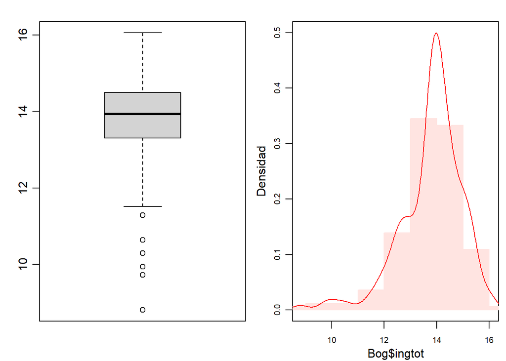

```r
# filtrar datos
Bog <- Data %>%
      filter(Dominio == "BOGOTA")
# mirar datos
par(mfrow = c(1,2), mar = c(2.75,2.75,1.5,0.5), mgp=c(1.7,0.7,0))
boxplot(Bog$Ingtot)
plot(x = NA, y = NA, ylab = "Densidad", xlab = "Bog$ingtot", cex.axis = 0.7, xlim = range(Bog$Ingtot),ylim = c(0,0.5))
hist(Bog$Ingtot, freq = F, add = T, col = "mistyrose", border = "mistyrose")
lines(density(Bog$Ingtot), col = "red")
```

```r
# datos almacenados en Estadisticos
yb_Bog <- as.numeric(Estadisticos[3,3])
yb_Bog
```

```
## [1] 13.79597
```

```r
n_Bog <- as.numeric(Estadisticos[3,2])
n_Bog
```

```
## [1] 165
```

```r
# desviación
des_Bog <- sd(Bog$Ingtot)
des_Bog
```

```
## [1] 1.173555
```

```r
#mediana
mediana_Bog <- median(Bog$Ingtot)
mediana_Bog
```

```
## [1] 13.93417
```

```r
#coeficiente de variación
cv_Bog <- des_Bog/yb_Bog
cv_Bog
```

```
## [1] 0.08506506
```

```r
# rango bógota
rango_Bog <- range(Bog$Ingtot)[2] - range(Bog$Ingtot)[1]
rango_Bog
```

```
## [1] 7.261927
```

```r
# rango intercuartilico
IQR_Bog <- IQR(Bog$Ingtot)
IQR_Bog
```

```
## [1] 1.198039
```

### Simulación

Haremos uso de la **Distribución predictiva posterior** para obtener las muestras de los estadisticos que nos permitan obtener el **ppp**

```r
#distribución predictiva posterior
yb_MCMC      <- NULL
mediana_MCMC <- NULL
des_MCMC     <- NULL
cv_MCMC      <- NULL
rango_MCMC   <- NULL
IQR_MCMC     <- NULL
#Muestreo
set.seed(1908) #año del artículo  Biometrika
for (i in 1:10000) {
      #datos
      y_pre <- rt.scaled(n = n_Bog, df = 3, mean = theta_Bog[i], sd = sqrt(sig2_Bog[i]))
      #estadisticas
      yb_MCMC[i]      <- mean(y_pre)
      mediana_MCMC[i] <- median(y_pre)
      des_MCMC[i]     <- sd(y_pre)
      cv_MCMC[i]      <- (sd(y_pre))/mean(y_pre)
      rango_MCMC[i]   <- range(y_pre)[2] - range(y_pre)[1]
      IQR_MCMC[i]     <- IQR(y_pre)
      }
```

Con lo anterior podemos encontrar los **PPP** para cada estadístico y presentarlos en un tabla

```r
# tabla de resumen
tab <- matrix(c(yb_Bog, quantile(yb_MCMC,probs = 0.025), mean(yb_MCMC), quantile(yb_MCMC,probs = 0.975), mean(yb_MCMC > yb_Bog),
                mediana_Bog, quantile(mediana_MCMC,probs = 0.025), mean(mediana_MCMC), quantile(mediana_MCMC,probs = 0.975), mean(mediana_MCMC > mediana_Bog),
                des_Bog, quantile(des_MCMC,probs = 0.025), mean(des_MCMC), quantile(des_MCMC,probs = 0.975), mean(des_MCMC > des_Bog),
                cv_Bog, quantile(cv_MCMC,probs = 0.025),  mean(cv_MCMC), quantile(cv_MCMC,probs = 0.975), mean(cv_MCMC > cv_Bog),
                rango_Bog, quantile(rango_MCMC,probs = 0.025), mean(rango_MCMC), quantile(rango_MCMC,probs = 0.975), mean(rango_MCMC > rango_Bog),
                IQR_Bog, quantile(IQR_MCMC,probs = 0.025), mean(IQR_MCMC), quantile(IQR_MCMC,probs = 0.975),
                mean(IQR_MCMC > IQR_Bog)),nrow = 6, ncol = 5, byrow = T)
colnames(tab) <- c("Observado", "Q2.5%", "Estimado", "Q97.5%","PPP")
rownames(tab) <- c("Media", "Q50%", "SD","CV", "Rango","IQR")
knitr::kable(x = tab, digits = 3, align = "c")
```

|  | Observado | Q2.5% | Estimado | Q97.5% | PPP |
| --- | --- | --- | --- | --- | --- |
| Media | 13.796 | 13.680 | 13.939 | 14.191 | 0.872 |
| Q50% | 13.934 | 13.719 | 13.940 | 14.160 | 0.520 |
| SD | 1.174 | 0.955 | 1.337 | 2.087 | 0.695 |
| CV | 0.085 | 0.068 | 0.096 | 0.150 | 0.669 |
| Rango | 7.262 | 6.236 | 12.008 | 26.082 | 0.906 |
| IQR | 1.198 | 0.928 | 1.207 | 1.532 | 0.507 |

## Ranking bayesiano

Usaremos el **modelo 6** para realizar un ranking bayesiano basado en las estimaciones puntuales y los intervalos de credibilidad dados para cada promedio por dominio teniendo en cuenta lo siguiente:

1. Hacer la visualización en escala logarítmica.
2. Rojo oscuro para efectos promedio significativamente inferiores a 13.830
3. Negro para efectos promedio que no difieren significativamente de 13.830
4. Verde oscuro para efectos promedio significativamente superiores a 13.830
5. Observe que 13.830 corresponde a un SMLMV de 2022 en escala logarítmica.

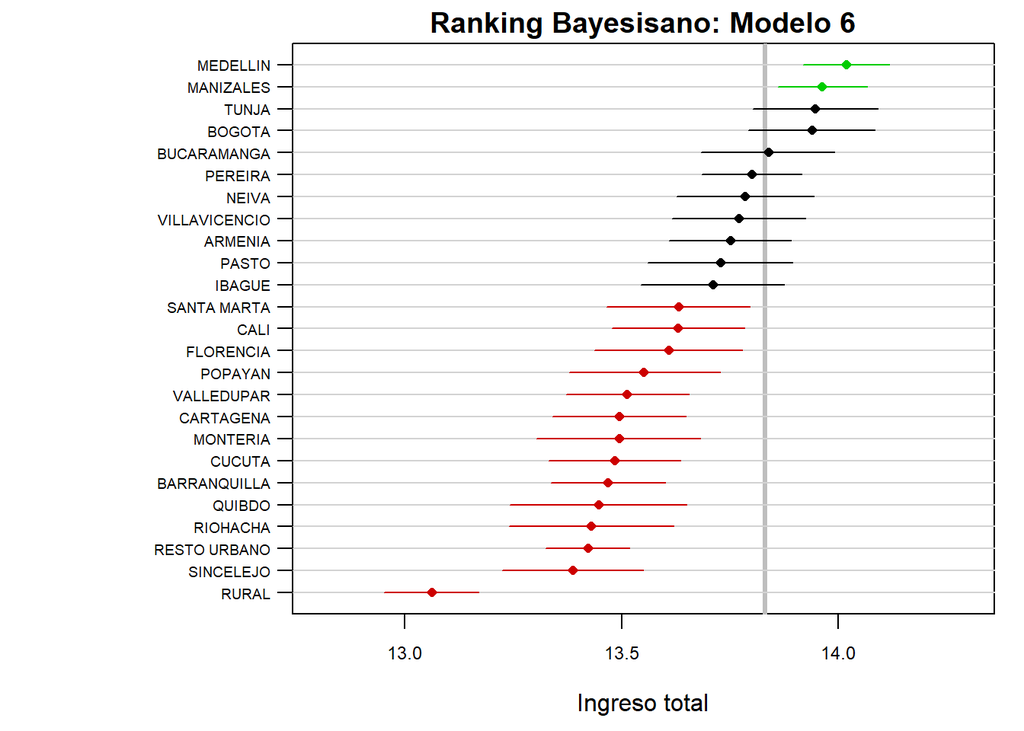

```r
#ranking
THETA    <- cadena1_M6$THETA
Dominios <- Estadisticos$Dominio
#Estimaciones puntuales
that <- colMeans(THETA[,1:m])
# Int. credibilidad al 95%
IC95 <- apply(X = THETA[,1:m], MARGIN = 2, FUN = function(x) quantile(x, c(0.025,0.975)))
# ordernar el ranking (menor a mayor)
orden    <- order(that)
Dominios <- Dominios[orden]
that     <- that[orden]
IC95     <- IC95[,orden]
# Colores
colo <- rep(2,m)
colo[which(IC95[1,]>13.830)] <- 1
colo[which(IC95[2,]<13.830)] <- 3
colo <- c("green3","black","red3")[colo]
#Gráfico
par(mfrow = c(1,1), mar = c(4,10,1.5,1), mgp = c(2.5,0.75,0))
plot(NA, NA, xlab = "Ingreso total", ylab = "", main = "Ranking Bayesisano: Modelo 6", xlim = c(12.8,14.3), ylim = c(1,m), cex.axis = 0.75, yaxt = "n")
axis(side = 2, at = 1:m, labels = Dominios, las = 2, cex.axis = 0.6)
abline(v = 13.830,  col = "gray", lwd = 3)
abline(h = 1:m, col = "lightgray", lwd = 1)
# intervalo y estimación puntual
for (j in 1:m) {
  segments(x0 = IC95[1,j], y0 = j, x1 = IC95[2,j], y1 = j, col = colo[j])
  lines(x = that[j], y = j, type = "p", pch = 16, cex = 0.8, col = colo[j])
}
```

## Estimaciones para el top 5 del ranking

Usando el **modelo 6** y de acuerdo con el ranking anterior el top 5 son los siguietnes domingos **dominios**:

1. Medellin
2. Manizales
3. Tunja
4. Bogota
5. Bucaramanga

Usaremos la **Distribución predictiva posterior** para poder estimar puntualmente la media, la desviación estandar y el coeficiente de variación de ada dominio.

```r
# informacion del top 5
THETA_top5 <- THETA[,c(11, 10, 23, 3, 4, 36, 35, 48, 28, 29)]
#Estimaciones
yb_top5 <- colMeans(THETA_top5[,1:5])
sd_top5 <- sqrt(3*colMeans(THETA_top5[,6:10]))
cv_top5 <- (sd_top5/yb_top5)
# pasar a escala normal
yb_top5 <- exp(yb_top5)
sd_top5 <- exp(sd_top5)
cv_top5 <- cv_top5
# tabla de resumen
tab <- matrix(c(yb_top5[1], yb_top5[2], yb_top5[3], yb_top5[4], yb_top5[5],
                sd_top5[1], sd_top5[2], sd_top5[3], sd_top5[4], sd_top5[5],
                cv_top5[1], cv_top5[2], cv_top5[3], cv_top5[4], cv_top5[5]),nrow = 3,
              ncol = 5, byrow = T)
colnames(tab) <- c("Med", "Man", "Tun","Bog", "Buca")
rownames(tab) <- c("Media","SD","CV%")
knitr::kable(x = tab, digits = 3, align = "c")
```

|  | Med | Man | Tun | Bog | Buca |
| --- | --- | --- | --- | --- | --- |
| Media | 1225592.314 | 1158832.449 | 1140575.937 | 1131724.376 | 1023513.016 |
| SD | 3.184 | 2.615 | 3.210 | 3.975 | 3.643 |
| CV% | 0.083 | 0.069 | 0.084 | 0.099 | 0.093 |

pruebas para deviacion bogota datos reales

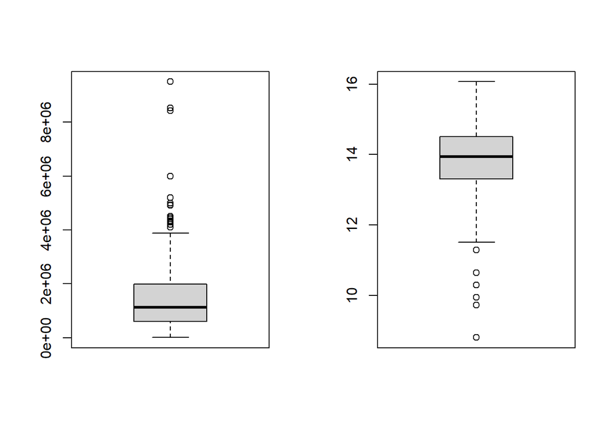

```r
# datos escala pesos
dataPrueba <- data.frame(dat$dominio, dat$ingtot)
#nombres
names(dataPrueba) <- c("Dominio","Ingtot")
# filtrar datos
BogPrueba <- dataPrueba %>%
      filter(Dominio == "BOGOTA")
# mirar datos
par(mfrow =c(1,2))
boxplot(BogPrueba$Ingtot)
boxplot(log(BogPrueba$Ingtot))
```

```r
# media
mean(BogPrueba$Ingtot)
```

```
## [1] 1611980
```

```r
#sd
sd(BogPrueba$Ingtot)
```

```
## [1] 1595613
```

Prueba para punto 6

exponenciandolos resultados de la tabla

```r
# informacion del top 5
THETA_top5 <-exp(THETA[,c(11, 10, 23, 3, 4, 36, 35, 48, 28, 29)])
#Estimaciones
yb_top5 <- colMeans(THETA_top5[,1:5])
sd_top5 <- sqrt(3*colMeans(THETA_top5[,6:10]))
cv_top5 <- (sd_top5/yb_top5)
# pasar a escala normal
#yb_top5 <- exp(yb_top5)
#sd_top5 <- exp(sd_top5)
# tabla de resumen
tab <- matrix(c(yb_top5[1], yb_top5[2], yb_top5[3], yb_top5[4], yb_top5[5],
                sd_top5[1], sd_top5[2], sd_top5[3], sd_top5[4], sd_top5[5],
                cv_top5[1], cv_top5[2], cv_top5[3], cv_top5[4], cv_top5[5]),nrow = 3,
              ncol = 5, byrow = T)
colnames(tab) <- c("Med", "Man", "Tun","Bog", "Buca")
rownames(tab) <- c("Media","SD","CV%")
knitr::kable(x = tab, digits = 3, align = "c")
```

|  | Med | Man | Tun | Bog | Buca |
| --- | --- | --- | --- | --- | --- |
| Media | 1227170.728 | 1160405.817 | 1143713.004 | 1134797.386 | 1026713.718 |
| SD | 2.168 | 2.022 | 2.177 | 2.385 | 2.295 |
| CV% | 0.000 | 0.000 | 0.000 | 0.000 | 0.000 |

## Segmentación jerárquica

```r
#install.packages("dendextend")
#install.packages("data.table")
#install.packages("factoextra")
#install.packages("factoextra")
#install.packages("grid")
#install.packages("datawizard")
suppressMessages(suppressWarnings(library(dendextend)))
suppressMessages(suppressWarnings(library(data.table)))
suppressMessages(suppressWarnings(library(factoextra)))
suppressMessages(suppressWarnings(library(cluster)))
suppressMessages(suppressWarnings(library(grid)))
suppressMessages(suppressWarnings(library(datawizard)))

theta  <- cadena1_M6$THETA[c(1:25)]
sigma2 <- sqrt(cadena1_M6$THETA[c(26:50)])
theta_est  <- colMeans(theta)
sigma2_est <- colMeans(sigma2)
arreglo <- data.frame(theta_est=normalize(theta_est),
                      sigma2_est=normalize(sigma2_est))
rownames(arreglo) <- unique(Data$Dominio)
arreglo
```

```
##               theta_est sigma2_est
## ARMENIA       0.7201664 0.52273294
## BARRANQUILLA  0.4251175 0.85175834
## BOGOTA        0.9167463 0.80402126
## BUCARAMANGA   0.8117394 0.64590083
## CALI          0.5943916 0.89045961
## CARTAGENA     0.4527467 0.62477336
## CUCUTA        0.4420739 0.47509117
## FLORENCIA     0.5723582 0.60295380
## IBAGUE        0.6787919 0.47453674
## MANIZALES     0.9414779 0.05916626
## MEDELLIN      1.0000000 0.41083324
## MONTERIA      0.4516693 0.94191133
## NEIVA         0.7562034 0.54292819
## PASTO         0.6962082 0.86741060
## PEREIRA       0.7729004 0.00000000
## POPAYAN       0.5121154 0.75688090
## QUIBDO        0.4035680 0.77836726
## RESTO URBANO  0.3779517 0.87132925
## RIOHACHA      0.3842626 0.93643946
## RURAL         0.0000000 0.84409213
## SANTA MARTA   0.5952344 0.91434186
## SINCELEJO     0.3403000 1.00000000
## TUNJA         0.9248864 0.42167904
## VALLEDUPAR    0.4714219 0.62354086
## VILLAVICENCIO 0.7410895 0.56828083
```

```r
# Paso 1: Calcular la matriz de distancias entre los dominios
dist_matrix <- get_dist(arreglo, method = "euclidian", stand = F)

# Paso 2: Realizar la agrupación jerárquica
set.seed(2013)
hclust_result <- hclust(dist_matrix, method = "complete")
# Paso 3: Obtener la segmentación en cuatro grupos
groups <- cutree(hclust_result, k = 4)

# Paso 4: Mostrar los resultados
results <- data.frame(Grupo = as.factor(groups), arreglo)
results
```

```
##               Grupo theta_est sigma2_est
## ARMENIA           1 0.7201664 0.52273294
## BARRANQUILLA      2 0.4251175 0.85175834
## BOGOTA            3 0.9167463 0.80402126
## BUCARAMANGA       3 0.8117394 0.64590083
## CALI              3 0.5943916 0.89045961
## CARTAGENA         4 0.4527467 0.62477336
## CUCUTA            4 0.4420739 0.47509117
## FLORENCIA         4 0.5723582 0.60295380
## IBAGUE            1 0.6787919 0.47453674
## MANIZALES         1 0.9414779 0.05916626
## MEDELLIN          1 1.0000000 0.41083324
## MONTERIA          2 0.4516693 0.94191133
## NEIVA             1 0.7562034 0.54292819
## PASTO             3 0.6962082 0.86741060
## PEREIRA           1 0.7729004 0.00000000
## POPAYAN           4 0.5121154 0.75688090
## QUIBDO            2 0.4035680 0.77836726
## RESTO URBANO      2 0.3779517 0.87132925
## RIOHACHA          2 0.3842626 0.93643946
## RURAL             2 0.0000000 0.84409213
## SANTA MARTA       3 0.5952344 0.91434186
## SINCELEJO         2 0.3403000 1.00000000
## TUNJA             1 0.9248864 0.42167904
## VALLEDUPAR        4 0.4714219 0.62354086
## VILLAVICENCIO     1 0.7410895 0.56828083
```

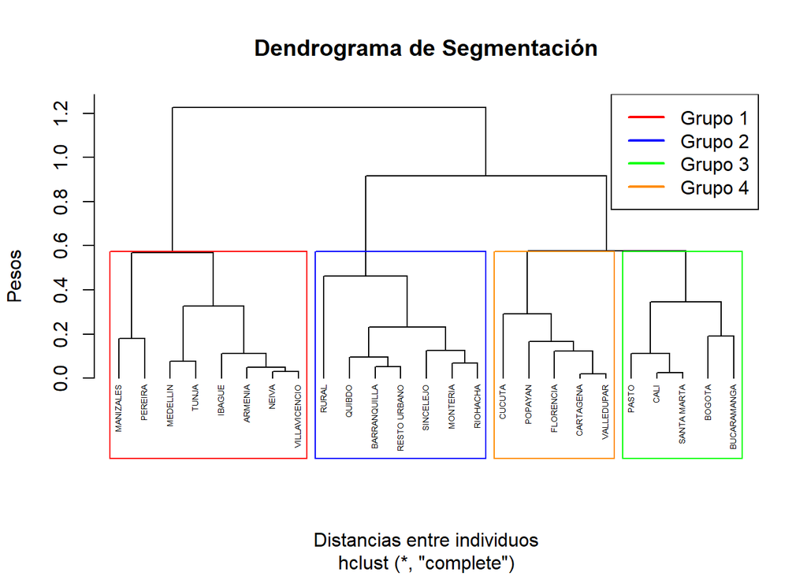

```r
# Paso 5: Ordenar los grupos y los colores según el orden de las ramas
order <- order.dendrogram(as.dendrogram(hclust_result))
groups <- groups[order]
colores <- c("red", "blue", "green", "darkorange")
colores_grupo <- colores[groups]

# Paso 6: Graficar el dendrograma con los nombres de las hojas
plot(hclust_result, main = "Dendrograma de Segmentación", cex= 0.45,
     xlab= "Distancias entre individuos", ylab="Pesos",check = T,ann = T, hang = -1)
rect.hclust(hclust_result, k = 4, border = unique(colores_grupo))
# Paso 7: Ajustar la leyenda
legend("topright", legend = c("Grupo 1", "Grupo 2", "Grupo 3", "Grupo 4"),
       col = colores, lty = 1, lwd = 2)
```

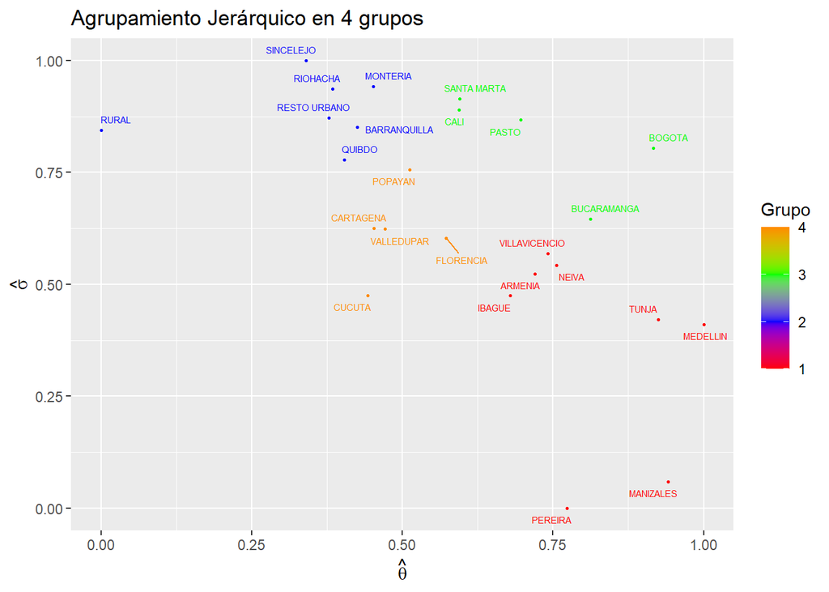

```r
# fviz_cluster(list(data = arreglo, cluster = groups))
library(ggrepel)
clases_aj <- cutree(hclust_result, k = 4)
results$Grupo <- clases_aj
results$Etiqueta <- rownames(results)
ggplot() + geom_text_repel(aes(x = theta_est, y = sigma2_est, color = Grupo, label = Etiqueta),
                           data = results, size = 2) +
      geom_point(aes(x = theta_est, y = sigma2_est, color = Grupo), data = results, size = 0.5) +
      scale_colour_gradientn(colours= colores) +
      ggtitle('Agrupamiento Jerárquico en 4 grupos') +
      xlab(expression(hat(theta))) + ylab(expression(hat(sigma)))
```